# NYPD Shooting Incident Analysis

2022-05-07

```r
library(tidyverse)
library("lubridate")
```

```r
library(ggplot2)
options(dplyr.summarise.inform = FALSE)
```

## Data Loading and Summary

I transformed data into factor.

```r
url_in <- "https://data.cityofnewyork.us/api/views/833y-fsy8/rows.csv?accessType=DOWNLOAD"
if (!(file.exists("./NYPD_Shooting_Incident_Data__Historic_.csv"))) {
  download.file(url_in, "./NYPD_Shooting_Incident_Data__Historic_.csv")
}

file_name <- "NYPD_Shooting_Incident_Data__Historic_.csv"
nypd_cases <- read_csv(file_name) %>%
  mutate(INCIDENT_KEY=as.factor(INCIDENT_KEY),
         OCCUR_DATE=mdy(OCCUR_DATE),
         OCCUR_TIME=c(OCCUR_TIME),
         YEAR = year(OCCUR_DATE),
         MONTH=month(OCCUR_DATE),
         BORO=as.factor(BORO),
         PRECINCT=as.factor(PRECINCT),
         JURISDICTION_CODE=as.factor(JURISDICTION_CODE),
         LOCATION_DESC=as.factor(LOCATION_DESC),
         STATISTICAL_MURDER_FLAG=as.factor(STATISTICAL_MURDER_FLAG),
         PERP_AGE_GROUP=as.factor(PERP_AGE_GROUP),
         PERP_SEX=as.factor(PERP_SEX),
         PERP_RACE=as.factor(PERP_RACE),
         VIC_AGE_GROUP=as.factor(VIC_AGE_GROUP),
         VIC_SEX=as.factor(VIC_SEX),
         VIC_RACE=as.factor(VIC_RACE),
         X_COORD_CD=as.factor(X_COORD_CD),
         Y_COORD_CD=as.factor(Y_COORD_CD),
         Latitude=as.factor(Latitude),
         Longitude=as.factor(Longitude),
         Lon_Lat=as.factor(Lon_Lat))
```

## Data description and analysis

Here is summary. This data set is dated from 2006-01-01 to 2020-12-31.  
There are big null value in LOCATION_DESC, PERP_AGE_GROUP, PERP_SEX, and PERP_RACE columns.  
So This data set has bias for perpetrator and locations.  
Even though null value in PERP_RACE is not small proportion (about 35%), I’ll remove records which PERP_RACE is null.  
Since it is hard to replace null by other value.

```r
summary(nypd_cases)
```

```
##     INCIDENT_KEY     OCCUR_DATE          OCCUR_TIME                  BORO
##  173354054:   18   Min.   :2006-01-01   Length:23585      BRONX        :6701
##  23749375 :   12   1st Qu.:2008-12-31   Class1:hms        BROOKLYN     :9734
##  24717013 :   12   Median :2012-02-27   Class2:difftime   MANHATTAN    :2922
##  33478089 :   12   Mean   :2012-10-05   Mode  :numeric    QUEENS       :3532
##  33706902 :   12   3rd Qu.:2016-03-02                     STATEN ISLAND: 696
##  35803777 :   12   Max.   :2020-12-31
##  (Other)  :23507
##     PRECINCT     JURISDICTION_CODE                   LOCATION_DESC
##  75     : 1375   0   :19629        MULTI DWELL - PUBLIC HOUS: 4240
##  73     : 1284   1   :   54        MULTI DWELL - APT BUILD  : 2553
##  67     : 1101   2   : 3900        PVT HOUSE                :  857
##  79     :  921   NA's:    2        GROCERY/BODEGA           :  574
##  44     :  841                     BAR/NIGHT CLUB           :  562
##  47     :  818                     (Other)                  : 1218
##  (Other):17245                     NA's                     :13581
##  STATISTICAL_MURDER_FLAG PERP_AGE_GROUP PERP_SEX              PERP_RACE
##  FALSE:19085             18-24  :5508   F   :  335   BLACK         :10025
##  TRUE : 4500             25-44  :4714   M   :13490   WHITE HISPANIC: 1988
##                          UNKNOWN:3148   U   : 1499   UNKNOWN       : 1836
##                          <18    :1368   NA's: 8261   BLACK HISPANIC: 1096
##                          45-64  : 495                WHITE         :  255
##                          (Other):  57                (Other)       :  124
##                          NA's   :8295                NA's          : 8261
##  VIC_AGE_GROUP   VIC_SEX                             VIC_RACE
##  <18    : 2525   F: 2204   AMERICAN INDIAN/ALASKAN NATIVE:    9
##  18-24  : 9003   M:21370   ASIAN / PACIFIC ISLANDER      :  327
##  25-44  :10303   U:   11   BLACK                         :16869
##  45-64  : 1541             BLACK HISPANIC                : 2245
##  65+    :  154             UNKNOWN                       :   65
##  UNKNOWN:   59             WHITE                         :  620
##                            WHITE HISPANIC                : 3450
##         X_COORD_CD           Y_COORD_CD                Latitude
##  1017119.4375:   66   183909.34375:   66   40.6714126050001:   66
##  1008276     :   47   183623      :   47   40.670655072    :   47
##  1026387     :   47   262634      :   47   40.887451313    :   47
##  936721.6875 :   44   172119.4375 :   44   40.6389853750001:   44
##  1017141     :   44   183798      :   44   40.671106911    :   44
##  1006434     :   42   244344      :   42   40.8373235110001:   42
##  (Other)     :23295   (Other)     :23295   (Other)         :23295
```

[output cut: 9 more lines]

```
##  POINT (-73.88151014499994 40.67141260500006) :   66   Min.   :2006
##  POINT (-73.84760778699996 40.88745131300004) :   47   1st Qu.:2008
##  POINT (-73.91339091999998 40.670655072000045):   47   Median :2012
##  POINT (-73.88143295699996 40.67110691100004) :   44   Mean   :2012
##  POINT (-74.17125343299995 40.63898537500006) :   44   3rd Qu.:2016
##  POINT (-73.91983075699994 40.83732351100008) :   42   Max.   :2020
##  (Other)                                      :23295
##      MONTH
##  Min.   : 1.000
##  1st Qu.: 5.000
##  Median : 7.000
##  Mean   : 6.856
##  3rd Qu.: 9.000
##  Max.   :12.000
##
```

```r
# Proportion of null value in LOCATION_DESC
sum(is.na(nypd_cases$LOCATION_DESC))/nrow(nypd_cases)
```

```
## [1] 0.5758321
```

```r
# Proportion of null value in PERP_AGE_GROUP
sum(is.na(nypd_cases$PERP_AGE_GROUP))/nrow(nypd_cases)
```

```
## [1] 0.3517066
```

```r
# Proportion of null value in PERP_SEX
sum(is.na(nypd_cases$PERP_SEX))/nrow(nypd_cases)
```

```
## [1] 0.350265
```

```r
# Proportion of null value in PERP_RACE
sum(is.na(nypd_cases$PERP_RACE))/nrow(nypd_cases)
```

```
## [1] 0.350265
```

```r
# Number of record which PERP_RACE is null in each year
nypd_cases %>%
  filter(is.na(nypd_cases$PERP_RACE)) %>%
  group_by(YEAR) %>%
  summarize(null_record_count = n())
```

| YEAR | null_record_count |
| --- | --- |
| 2006 | 131 |
| 2007 | 281 |
| 2008 | 222 |
| 2009 | 189 |
| 2010 | 698 |
| 2011 | 947 |
| 2012 | 892 |
| 2013 | 641 |
| 2014 | 731 |
| 2015 | 668 |

[output cut: 5 more lines]

```r
nypd_cases <- nypd_cases %>%
  filter(!is.na(PERP_RACE))
```

## Objective of report

I’d like to look into this data to check if there is racism in New York.

This analysis may hurt someone who is sensitive to racism, I hope you understand that **this analysis is data perspective.**

Firstly, let’s see what race has been arrested most and what race has been damaged in New York.

## The 7 most victims and perpetrator in New York

```r
nypd_vict <- nypd_cases %>%
  group_by(VIC_RACE) %>%
  summarize(count_vic_race = n()) %>%
  mutate(VIC_PROP = count_vic_race / nrow(nypd_cases)) %>%
  slice_max(order_by = count_vic_race, n=10)
```

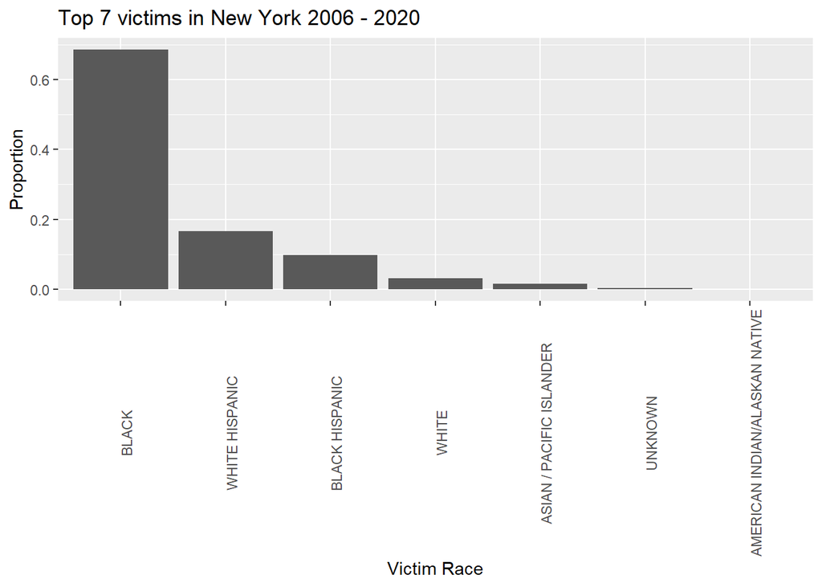

```r
ggplot(nypd_vict, aes(x=reorder(VIC_RACE,-VIC_PROP), y=VIC_PROP)) +
  geom_bar(stat = "identity", position="dodge") +
  theme(axis.text.x = element_text(angle = 90)) +
  ggtitle("Top 7 victims in New York 2006 - 2020") +
  xlab("Victim Race") +
  ylab("Proportion")
```

```r
nypd_perp <- nypd_cases %>%
  group_by(PERP_RACE) %>%
  summarize(count_perp_race = n()) %>%
  mutate(PERP_PROP = count_perp_race / nrow(nypd_cases)) %>%
  slice_max(order_by = count_perp_race, n=10)
```

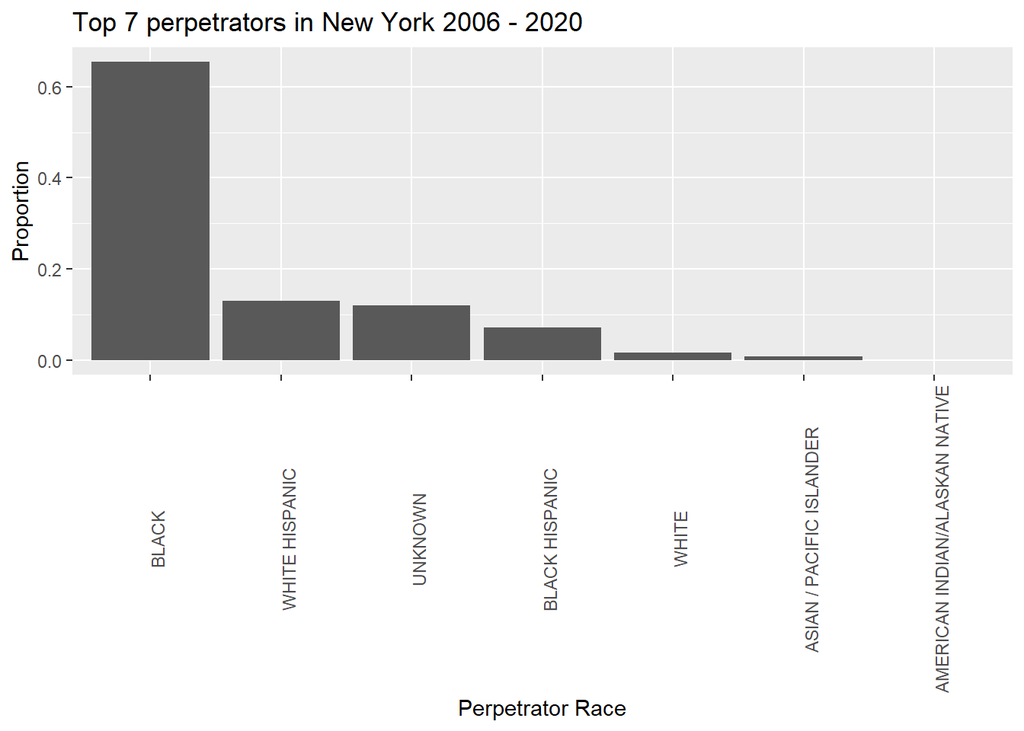

```r
ggplot(nypd_perp, aes(x=reorder(PERP_RACE,-PERP_PROP), y=PERP_PROP)) +
  geom_bar(stat = "identity", position="dodge") +
  theme(axis.text.x = element_text(angle = 90)) +
  ggtitle("Top 7 perpetrators in New York 2006 - 2020") +
  xlab("Perpetrator Race") +
  ylab("Proportion")
```

AS we can see on the above graph,  
The **black** people are the most perpetrator and victims at the same time *between 2006 and 2020*.  
about **70% of victim is the black** and about **65% of perpetrator is the black**.  
(Cases that perpetrator information is missing is excluded)

Then what races were the biggest victims of the Black’s crime and what races shot the Black most?

```r
nypd_cases_perp_to_vic <- nypd_cases %>%
  group_by(PERP_RACE, VIC_RACE) %>%
  summarize(count_incident = n()) %>%
  mutate(vic_prop = count_incident / sum(count_incident),
         prep_prop = count_incident / nrow(nypd_cases)) %>%
  filter(PERP_RACE!='AMERICAN INDIAN/ALASKAN NATIVE')
```

## Perpetrator - Victim pair race bar chart

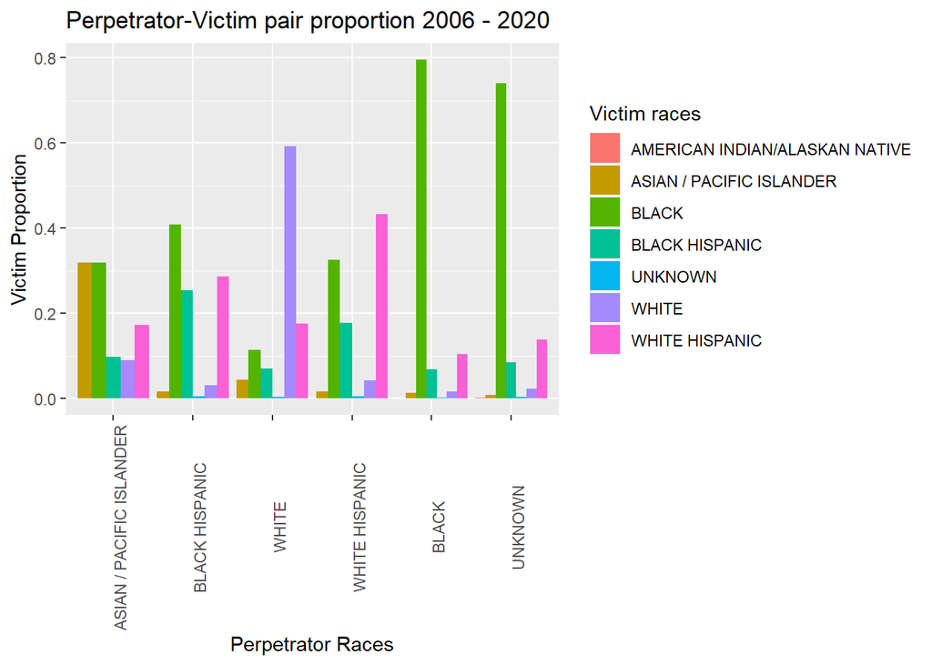

```r
ggplot(nypd_cases_perp_to_vic, aes(fill=VIC_RACE, x=reorder(PERP_RACE,-vic_prop), y=vic_prop)) +
  geom_bar(stat = "identity", position="dodge") +
  theme(axis.text.x = element_text(angle = 90)) +
  ggtitle("Perpetrator-Victim pair proportion 2006 - 2020") +
  xlab("Perpetrator Races") +
  ylab("Victim Proportion") +
  labs(fill="Victim races")
```

The answer is the Black for both cases.  
**During 2006 - 2020, most shooting incident happened by the Black and the victim of the incidents were the Black too in New York.**

Let’s check if this trend is overall or happened in some specific cases.

## Shooting incident yearly trend

```r
nypd_cases_perp_year <- nypd_cases %>%
  group_by(YEAR,PERP_RACE) %>%
  summarize(count_incident = n()) %>%
  mutate(PERP_PROP = count_incident / sum(count_incident))
```

```r
nypd_cases_vic_year <- nypd_cases %>%
  group_by(YEAR,VIC_RACE) %>%
  summarize(count_incident = n()) %>%
  mutate(VIC_PROP = count_incident / sum(count_incident))
```

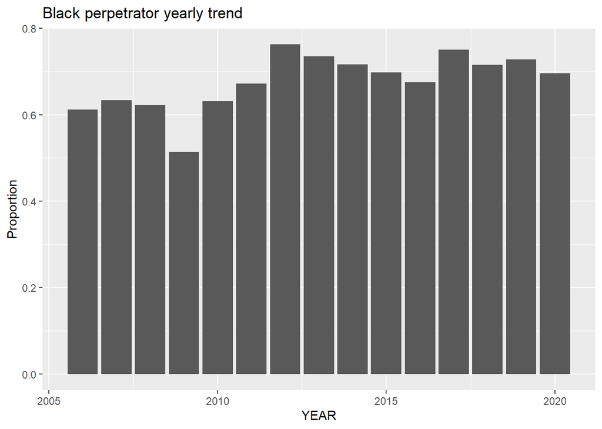

```r
nypd_cases_black_perp_year <- nypd_cases_perp_year %>% filter(PERP_RACE == 'BLACK')
ggplot(nypd_cases_black_perp_year, aes(x=YEAR, y=PERP_PROP)) +
  geom_bar(stat = "identity", position="dodge") +
  ggtitle("Black perpetrator yearly trend") +
  ylab("Proportion")
```

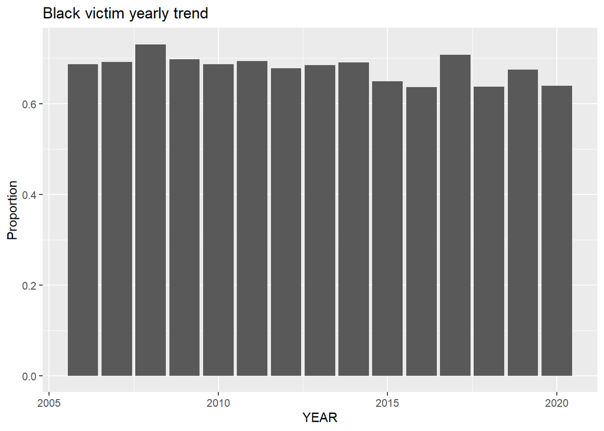

```r
nypd_cases_black_vic_year <- nypd_cases_vic_year %>% filter(VIC_RACE == 'BLACK')
ggplot(nypd_cases_black_vic_year, aes(x=YEAR, y=VIC_PROP)) +
  geom_bar(stat = "identity", position="dodge") +
  ggtitle("Black victim yearly trend") +
  ylab("Proportion")
```

## Victim proprtion yearly trend by the Black

```r
nypd_cases_perp_to_vic_year <- nypd_cases %>%
  group_by(YEAR, PERP_RACE, VIC_RACE) %>%
  summarize(count_incident = n()) %>%
  mutate(perp_vic_prop = count_incident / sum(count_incident))
```

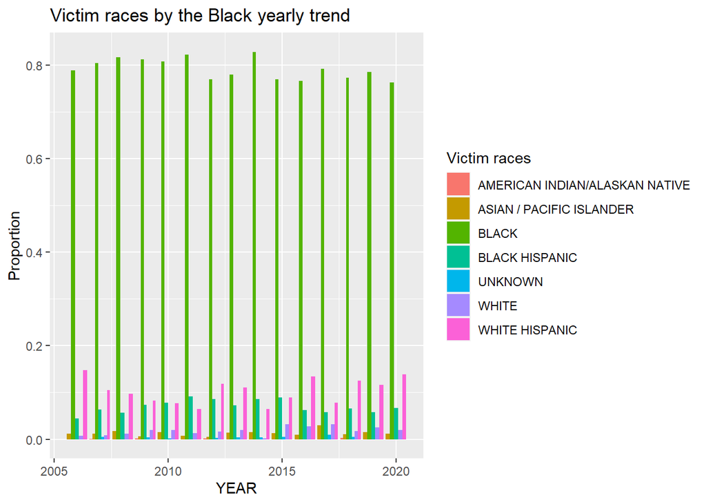

```r
nypd_cases_perp_to_vic_black_year <- nypd_cases_perp_to_vic_year %>% filter(PERP_RACE == 'BLACK')
ggplot(nypd_cases_perp_to_vic_black_year, aes(fill=VIC_RACE, x=YEAR, y=perp_vic_prop)) +
  geom_bar(stat = "identity", position = "dodge") +
  ggtitle("Victim races by the Black yearly trend") +
  ylab("Proportion") +
  labs(fill="Victim races")
```

## Conclusion

The phenomenon that we observed in overall data also occurred every year.  
The Black shot the Black most.

Therefore, at least, for the shooting incident, It is hard to see that there is some racism.  
But as I mentioned above, there are big null values which can cause bias.

## Modeling - Victim Trend Prediction

```r
mod <- lm(VIC_PROP ~ YEAR, data = nypd_cases_black_vic_year)
df <- data.frame(YEAR=c(2021,2022,2023,2024,2025))
pred <- predict(mod, df)
df$VIC_PROP <- pred
```

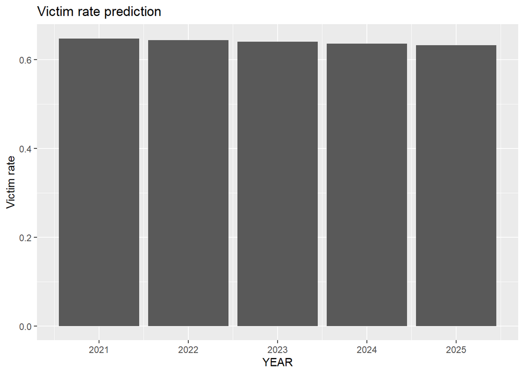

```r
ggplot(df, aes(x=YEAR, y=VIC_PROP)) +
  geom_bar(stat="identity", position="dodge") +
  ggtitle("Victim rate prediction") +
  ylab("Victim rate")
```

I predicted how victim proportion will be.  
It is such a simple model which uses only YEAR as feature.  
Victim rate will be declined slightly if current trend is maintained.

To decrease shooting incident in New York, it is necessary to solve issues in the Black society. But with this trend, it will take long time.  
New York need to provide some help on the Black society.